# **Reporte de Artesanos**

Juan Camilo

2023-03-26

## **Análisis Registro Nacional De Artesano - RNA**

Este es un breve reporte del análisis exploratorio de los Artesanos Inscritos en el Registro Nacional De Artesano - RNA por línea Artesanal y por Provincia [Gobierno Regional Piura]

**Datos disponibles en:** [Datos Registro de Artesanos](https://www.datosabiertos.gob.pe/dataset/artesanos-inscritos-en-el-registro-nacional-de-artesano-rna-por-l%C3%ADnea-artesanal-y-por)

### **Cargamos los paquetes**

```r
# Paquetes

library(readxl)
library(tidyverse)

library(sf)
library(purrr)
library(tidyverse)
library(ggplot2)
library(ggrepel)
```

### **Cargamos los datos**

```r
# Configurar el directorio de trabajo
setwd("D:/Cursos22/Analitica2023/TFinalEP/Analisis_Artesanos")

df <- read.csv("artesanosrnagrp_0.csv", sep = ",")
head(df)
```

```
##   FECHA_CORTE FECHA_MUESTRA UBIGEO DEPARTAMENTO PROVINCIA DISTRITO
## 1    20220306      20221227 200105        Piura     Piura Catacaos
## 2    20220306      20221227 200101        Piura     Piura    Piura
## 3    20220306      20221227 200105        Piura     Piura Catacaos
## 4    20220306      20221227 200105        Piura     Piura Catacaos
## 5    20220306      20221227 200105        Piura     Piura Catacaos
## 6    20220306      20221227 200105        Piura     Piura Catacaos
##                                   SOLICITANTE
## 1 EMPRESA DE LA ACTIVIDAD ARTESANAL (con ruc)
## 2 EMPRESA DE LA ACTIVIDAD ARTESANAL (con ruc)
## 3 EMPRESA DE LA ACTIVIDAD ARTESANAL (con ruc)
## 4 EMPRESA DE LA ACTIVIDAD ARTESANAL (con ruc)
## 5                     ASOCIACION DE ARTESANOS
## 6                     ASOCIACION DE ARTESANOS
##                                                                                  NOMBRE_O_RAZON_SOCIAL
```

[output cut: 27 more lines]

### **Primeros pasos con los datos**

```r
summary(df$UBIGEO)
```

```
##    Min. 1st Qu.  Median    Mean 3rd Qu.    Max.    NA's
##  200101  200105  200105  200241  200401  200806     119
```

```r
colSums(is.na(df))
```

```
##           FECHA_CORTE         FECHA_MUESTRA                UBIGEO
##                   119                   119                   119
##          DEPARTAMENTO             PROVINCIA              DISTRITO
##                     0                     0                     0
##           SOLICITANTE NOMBRE_O_RAZON_SOCIAL             DIRECCION
##                     0                     0                     0
##       TIPO._DOCUMENTO   NUMERO_DE_DOCUMENTO                ESTADO
##                     0                   119                     0
##       TIPO_CONSTANCIA     NUMERO_CONSTANCIA       LINEA_ARTESANAL
##                     0                   119                     0
##    SUBLINEA_ARTESANAL
##                     0
```

Eliminamos los ultimos 119 valores, son celdas vacias

```r
df <-  df %>%
  drop_na()

colSums(is.na(df))
```

```
##           FECHA_CORTE         FECHA_MUESTRA                UBIGEO
##                     0                     0                     0
##          DEPARTAMENTO             PROVINCIA              DISTRITO
##                     0                     0                     0
##           SOLICITANTE NOMBRE_O_RAZON_SOCIAL             DIRECCION
##                     0                     0                     0
##       TIPO._DOCUMENTO   NUMERO_DE_DOCUMENTO                ESTADO
##                     0                     0                     0
##       TIPO_CONSTANCIA     NUMERO_CONSTANCIA       LINEA_ARTESANAL
##                     0                     0                     0
##    SUBLINEA_ARTESANAL
##                     0
```

### **Analisis descriptivo univariado**

**Analicemos el numero de artesanos por provincia**

```r
Num_Artesanos <- df %>%
  group_by(PROVINCIA) %>%
  summarize(N_Artesanos = n()) %>%
  # ordenar el dataframe por la columna PRomedioMOnto
  arrange(desc(N_Artesanos))
Num_Artesanos
```

| PROVINCIA | N_Artesanos |
| --- | --- |
| Piura | 2400 |
| Morropon | 533 |
| Ayabaca | 231 |
| Talara | 186 |
| Sechura | 172 |
| Paita | 128 |
| Sullana | 93 |
| Huancabamba | 42 |

Visualicemos mediante un grafico

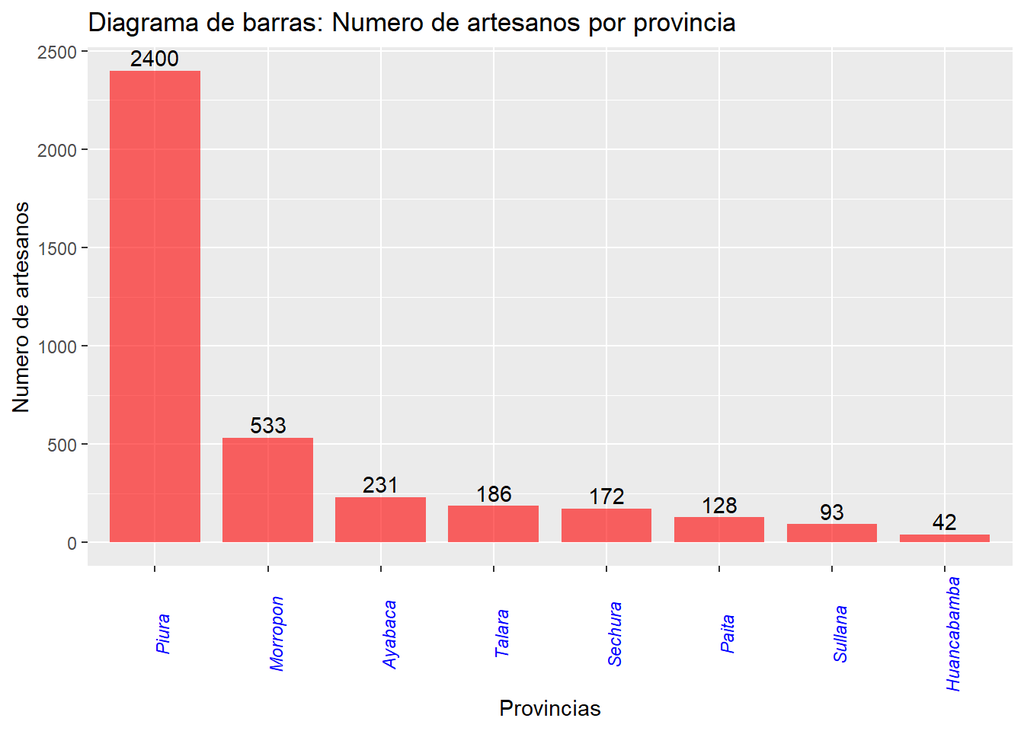

```r
Num_Artesanos %>%
  ggplot(mapping = aes(x = reorder(PROVINCIA, desc(N_Artesanos)), y = N_Artesanos)) +
  #geom_col() +
  geom_bar(stat = "identity", fill = "red", alpha = 0.6, width = 0.8)+
  theme(axis.text.x = element_text(angle = 90, face = "italic", colour = "blue"))+
  #coord_flip()+
  geom_text(aes(label = N_Artesanos), vjust = -0.3) +
  labs(x="Provincias",y= "Numero de artesanos")  +
  #ylim(c(0,300)) +
  ggtitle("Diagrama de barras: Numero de artesanos por provincia")
```

**Analicemos el numero de artesanos por distrito**

```r
Num_Art2 <- df %>%
  group_by(DISTRITO) %>%
  summarize(N_Artesanos = n()) %>%
  # ordenar el dataframe por la columna PRomedioMOnto
  arrange(desc(N_Artesanos))
Num_Art2
```

| DISTRITO | N_Artesanos |
| --- | --- |
| Catacaos | 1846 |
| Chulucanas | 476 |
| Castilla | 315 |
| Ayabaca | 136 |
| Mancora | 89 |
| Pacaipampa | 84 |
| La Arena | 80 |
| Piura | 76 |
| Sullana | 68 |
| Sechura | 60 |
| Parinas | 58 |
| Bernal | 49 |
| Chalaco | 49 |
| Paita | 48 |
| Vice | 40 |
| La Huaca | 39 |
| Cura Mori | 38 |
| El Carmen De La Frontera | 35 |
| Veintiseis De Octubre | 26 |
| Colan | 24 |
| Los Organos | 23 |
| Salitral | 20 |
| Rinconada Llicuar | 19 |
| La Union | 18 |
| Vichayal | 17 |
| El Alto | 15 |
| Frias | 8 |
| Bellavista | 6 |
| Santo Domingo | 5 |
| Sondorillo | 5 |
| Suyo | 3 |
| Bellavista De La Union | 2 |
| Cristo Nos Valga | 2 |
| Querecotillo | 2 |
| El Tallan | 1 |
| Huancabamba | 1 |
| La Brea | 1 |
| San Miguel De El Faique | 1 |

Visualicemos mediante un grafico

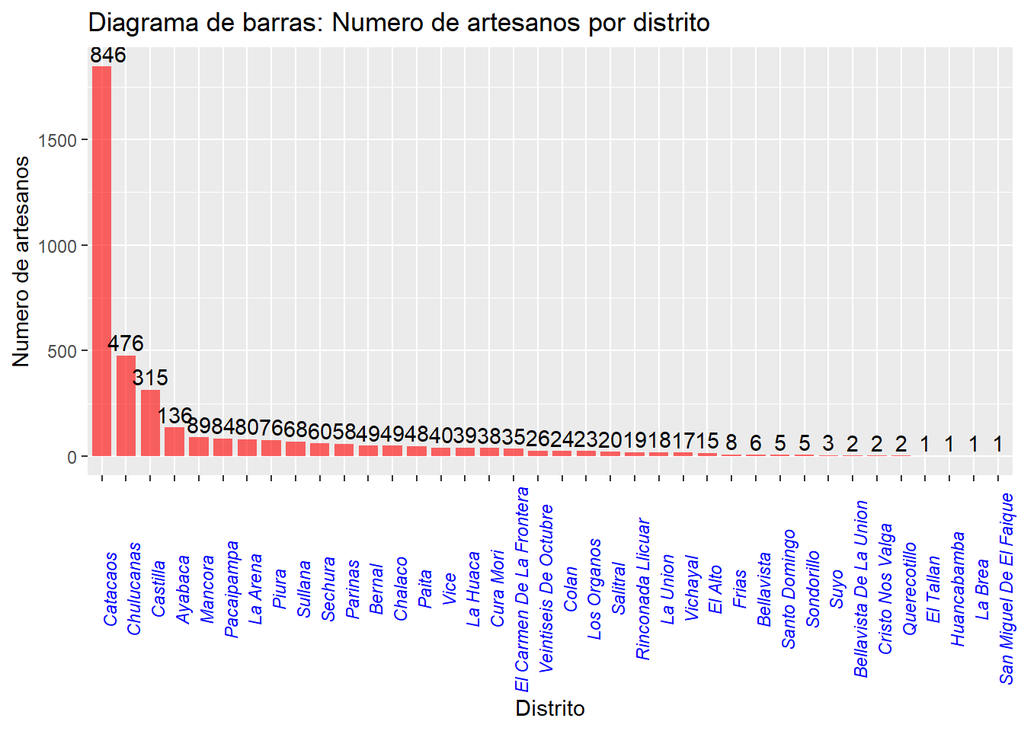

```r
Num_Art2 %>%
  ggplot(mapping = aes(x = reorder(DISTRITO, desc(N_Artesanos)), y = N_Artesanos)) +
  #geom_col() +
  geom_bar(stat = "identity", fill = "red", alpha = 0.6, width = 0.8)+
  theme(axis.text.x = element_text(angle = 90, face = "italic", colour = "blue"))+
  #coord_flip()+
  geom_text(aes(label = N_Artesanos), vjust = -0.3) +
  labs(x="Distrito",y= "Numero de artesanos")  +
  #ylim(c(0,300)) +
  ggtitle("Diagrama de barras: Numero de artesanos por distrito")
```

**Analicemos la inscripcion de artesanos por clase solicitante**

```r
Art_sol <- df %>%
  group_by(SOLICITANTE) %>%
  summarize(N_Artesanos = n()) %>%
  # ordenar el dataframe por la columna PRomedioMOnto
  arrange(desc(N_Artesanos))
Art_sol
```

| SOLICITANTE | N_Artesanos |
| --- | --- |
| ARTESANO | 3762 |
| ASOCIACION DE ARTESANOS | 19 |
| EMPRESA DE LA ACTIVIDAD ARTESANAL (con ruc) | 4 |

Visualicemos mediante un grafico

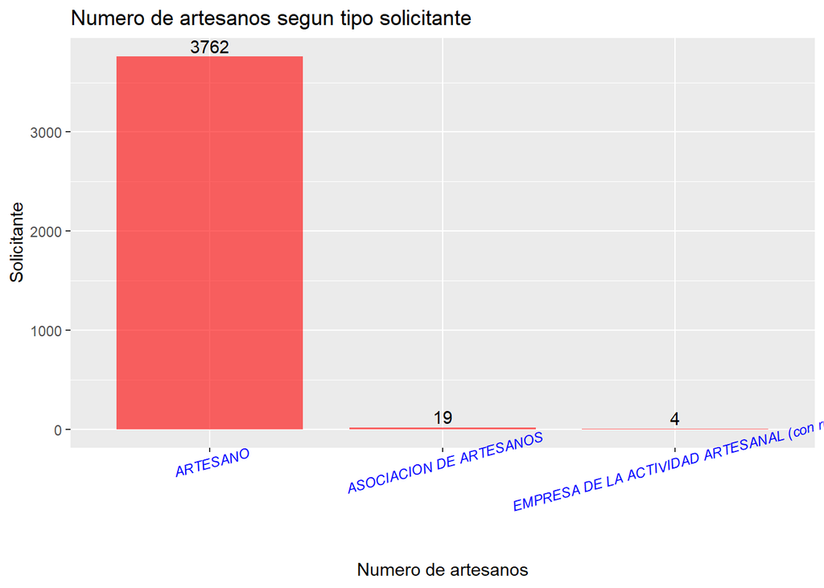

```r
Art_sol %>%
  ggplot(mapping = aes(x = reorder(SOLICITANTE, desc(N_Artesanos)), y = N_Artesanos)) +
  #geom_col() +
  geom_bar(stat = "identity", fill = "red", alpha = 0.6, width = 0.8)+
  theme(axis.text.x = element_text(angle = 15, face = "italic", colour = "blue"))+
  #coord_flip()+
  geom_text(aes(label = N_Artesanos), vjust = -0.3) +
  labs(x="Numero de artesanos",y= "Solicitante")  +
  #ylim(c(0,300)) +
  ggtitle("Numero de artesanos segun tipo solicitante")
```

**Analicemos el numero de artesanos segun su estado**

```r
Art_estado <- df %>%
  group_by(ESTADO) %>%
  summarize(N_Artesanos = n()) %>%
  # ordenar el dataframe por la columna PRomedioMOnto
  arrange(desc(N_Artesanos))
Art_estado
```

| ESTADO | N_Artesanos |
| --- | --- |
| APROBADO | 3785 |

Visualicemos mediante un grafico

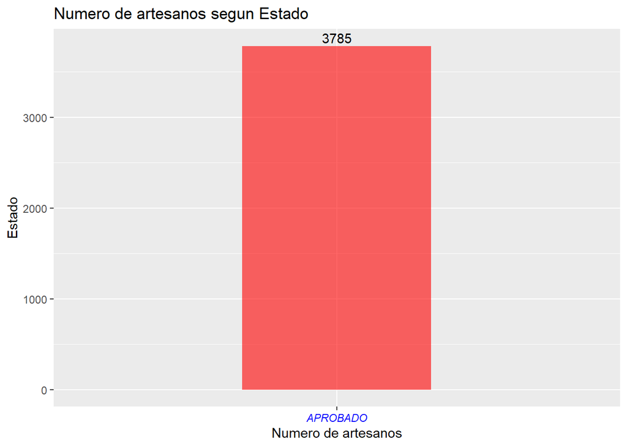

```r
Art_estado %>%
  ggplot(mapping = aes(x = reorder(ESTADO, desc(N_Artesanos)), y = N_Artesanos)) +
  #geom_col() +
  geom_bar(stat = "identity", fill = "red", alpha = 0.6, width = 0.4)+
  theme(axis.text.x = element_text(angle = 0, face = "italic", colour = "blue"))+
  #coord_flip()+
  geom_text(aes(label = N_Artesanos), vjust = -0.3) +
  labs(x="Numero de artesanos",y= "Estado")  +
  #ylim(c(0,300)) +
  ggtitle("Numero de artesanos segun Estado")
```

**Analicemos el numero de artesanos segun tipo de constancia**

```r
Art_const <- df %>%
  group_by(TIPO_CONSTANCIA) %>%
  summarize(N_Artesanos = n()) %>%
  # ordenar el dataframe por la columna PRomedioMOnto
  arrange(desc(N_Artesanos))
Art_const
```

| TIPO_CONSTANCIA | N_Artesanos |
| --- | --- |
| ART | 3762 |
| ASO | 19 |
| EMP | 4 |

Visualicemos mediante un grafico

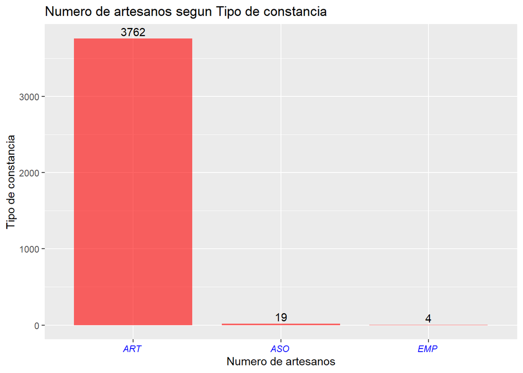

```r
Art_const %>%
  ggplot(mapping = aes(x = reorder(TIPO_CONSTANCIA, desc(N_Artesanos)), y = N_Artesanos)) +
  #geom_col() +
  geom_bar(stat = "identity", fill = "red", alpha = 0.6, width = 0.8)+
  theme(axis.text.x = element_text(angle = 0, face = "italic", colour = "blue"))+
  #coord_flip()+
  geom_text(aes(label = N_Artesanos), vjust = -0.3) +
  labs(x="Numero de artesanos",y= "Tipo de constancia")  +
  #ylim(c(0,300)) +
  ggtitle("Numero de artesanos segun Tipo de constancia")
```

**Analicemos el numero de artesanos segun lineaartesanal**

```r
Art_linart <- df %>%
  group_by(LINEA_ARTESANAL) %>%
  summarize(N_Artesanos = n()) %>%
  # ordenar el dataframe por la columna PRomedioMOnto
  arrange(desc(N_Artesanos))
Art_linart
```

| LINEA_ARTESANAL | N_Artesanos |
| --- | --- |
| Fibras Vegetales | 1699 |
| Textileria | 571 |
| Alfareria Y Ceramica | 560 |
| Joyeria Y Orfebreria | 439 |
| Bisuteria | 136 |
| Talla | 129 |
| Recurso Acuicola | 106 |
| Cueros Y Pieles | 67 |
| Pintura | 67 |
| Metalisteria | 4 |
| Mates Y Huingos | 2 |
| Vidrio | 2 |
| Cereria | 1 |
| Imagineria | 1 |
| Instrumentos Musicales | 1 |

Visualicemos mediante un grafico

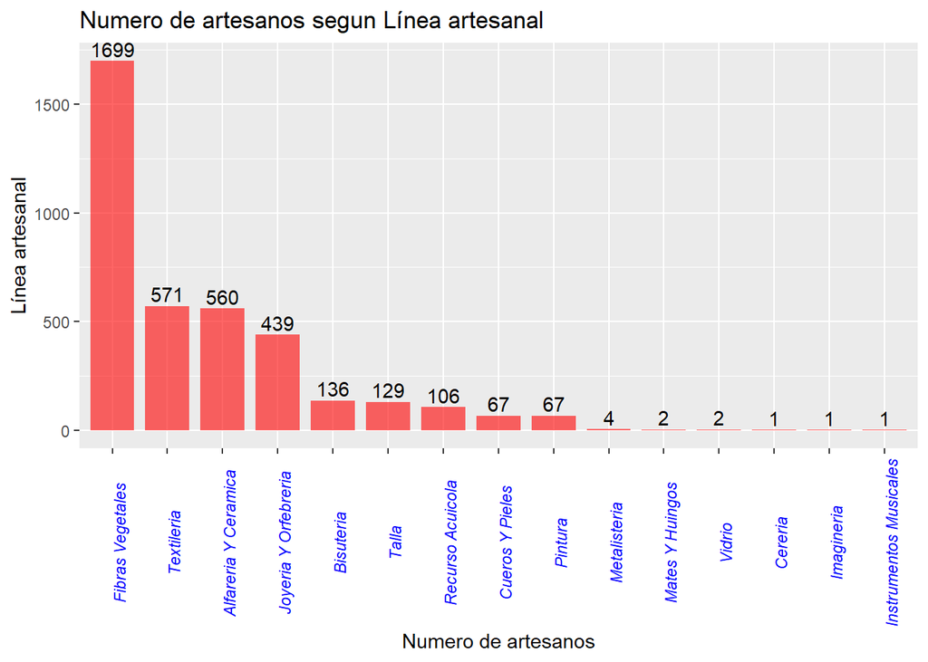

```r
Art_linart %>%
  ggplot(mapping = aes(x = reorder(LINEA_ARTESANAL, desc(N_Artesanos)), y = N_Artesanos)) +
  #geom_col() +
  geom_bar(stat = "identity", fill = "red", alpha = 0.6, width = 0.8)+
  theme(axis.text.x = element_text(angle = 90, face = "italic", colour = "blue"))+
  #coord_flip()+
  geom_text(aes(label = N_Artesanos), vjust = -0.3) +
  labs(x="Numero de artesanos",y= "Línea artesanal")  +
  #ylim(c(0,300)) +
  ggtitle("Numero de artesanos segun Línea artesanal")
```

**Analicemos el numero de artesanos segun sub lineaartesanal**

```r
Art_sblinart <- df %>%
  group_by(SUBLINEA_ARTESANAL) %>%
  summarize(N_Artesanos = n()) %>%
  # ordenar el dataframe por la columna PRomedioMOnto
  arrange(desc(N_Artesanos))
Art_sblinart
```

| SUBLINEA_ARTESANAL | N_Artesanos |
| --- | --- |
| Fibras Blandas | 1627 |
| Joyeria | 409 |
| Ceramica De Alta Temperatura O Loza Compacta | 332 |
| Tejido De Punto | 306 |
| Alfareria O Loza Porosa | 228 |
| Tejido En Telar O Tejido Plano | 142 |
| Madera | 125 |
| Recurso Marino | 106 |
| Inorganicos | 90 |
| Tejido A Mano | 79 |
| Fibras Duras | 72 |
| Pintura Popular | 65 |
| Talabarteria | 63 |
| Organicos | 46 |
| Bordados Y Aplicaciones | 36 |
| Orfebreria | 30 |
| Tela Tenida Y Pintada | 5 |
| Peleteria | 4 |
| Telas No Tejidas | 3 |
| Fierro O Hierro | 2 |
| Hojalata | 2 |
| Mates (Lagenaria Vulgaris) | 2 |
| Vidrio Pintado | 2 |
| Cascaras | 1 |
| Hueso | 1 |
| Imagineria Contemporanea | 1 |
| Instrumentos De Viento | 1 |
| Parafina | 1 |
| Piedra | 1 |
| Pintura (Estilo) Colonial | 1 |
| Pintura De Pueblos Originarios Amazonicos | 1 |
| Semillas Y Pepas | 1 |

Visualicemos mediante un grafico

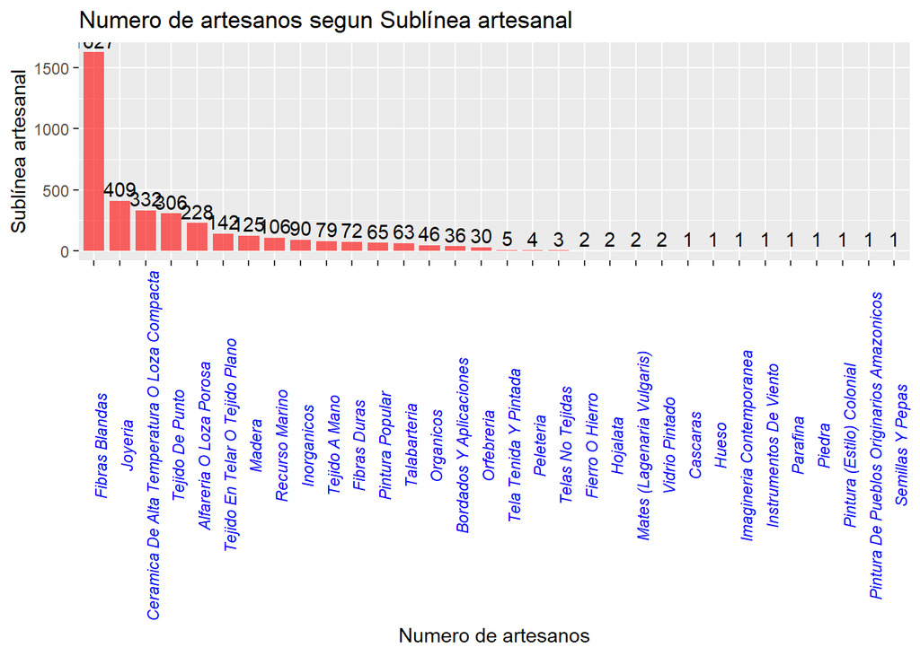

```r
Art_sblinart %>%
  ggplot(mapping = aes(x = reorder(SUBLINEA_ARTESANAL, desc(N_Artesanos)), y = N_Artesanos)) +
  #geom_col() +
  geom_bar(stat = "identity", fill = "red", alpha = 0.6, width = 0.8)+
  theme(axis.text.x = element_text(angle = 90, face = "italic", colour = "blue"))+
  #coord_flip()+
  geom_text(aes(label = N_Artesanos), vjust = -0.3) +
  labs(x="Numero de artesanos",y= "Sublínea artesanal")  +
  #ylim(c(0,300)) +
  ggtitle("Numero de artesanos segun Sublínea artesanal")
```

### **Mapas**

Realicemos mapas provinciales y distritales para conocer la distribucion de los artesanos piuranos

### **Mapa provincial**

Cargamos shp provincial y distrital

```r
## Carguemos el shp por provincias
m_provincias <- read_sf("MProv/PROVINCIAS_inei_geogpsperu_suyopomalia.shp")
head(m_provincias)
```

```
## Simple feature collection with 6 features and 79 fields
## Geometry type: MULTIPOLYGON
## Dimension:     XY
## Bounding box:  xmin: -78.71089 ymin: -6.986759 xmax: -77.1323 ymax: -2.986125
## Geodetic CRS:  WGS 84
## # A tibble: 6 × 80
##   OBJECTID NOMBDEP  IDPROV CCPP  CCDD  NOMBPROV   FUENTE POB_P…¹ POBTO…² POB_E…³
##      <dbl> <chr>    <chr>  <chr> <chr> <chr>      <chr>    <dbl>   <dbl>   <dbl>
## 1        1 AMAZONAS 0101   01    01    CHACHAPOY… INEI …   63188   60419   45859
## 2        2 AMAZONAS 0102   02    01    BAGUA      INEI …   84672   82193   56236
## 3        3 AMAZONAS 0103   03    01    BONGARA    INEI …   26830   27085   19924
## 4        4 AMAZONAS 0104   04    01    CONDORCAN… INEI …   51344   49800   27490
## 5        5 AMAZONAS 0105   05    01    LUYA       INEI …   47827   48140   34016
## 6        6 AMAZONAS 0106   06    01    RODRIGUEZ… INEI …   33651   32130   22758
## # … with 70 more variables: POB_EDAD_1 <dbl>, POB_EDAD_E <dbl>,
## #   POB_EDAD_2 <dbl>, DENSIDAD <dbl>, POBMASCU <dbl>, POBFEMEN <dbl>,
## #   POBMASCU_P <dbl>, POBFEMEN_P <dbl>, R_MASCULIN <dbl>, POBURBANA <dbl>,
## #   POBRURAL <dbl>, POBURBANA_ <dbl>, POBRURAL_P <dbl>, EDAD_PROME <dbl>,
## #   EDAD_MEDIA <dbl>, POB_0_14 <dbl>, POB_0_14_P <dbl>, POB_15_29 <dbl>,
## #   POB_15_29_ <dbl>, POB_30_59 <dbl>, POB_30_59_ <dbl>, POB_60_MAS <dbl>,
## #   POB_60_M_1 <dbl>, POB_ANALFA <dbl>, POB_ANAL_1 <dbl>, HOMBRES_AN <dbl>, …
```

```r
## Carguemos el shp por distritos
m_distritos<- read_sf("MDist/DISTRITOS_inei_geogpsperu_suyopomalia.shp")
head(m_distritos)
```

```
## Simple feature collection with 6 features and 77 fields
## Geometry type: MULTIPOLYGON
## Dimension:     XY
## Bounding box:  xmin: -75.94789 ymin: -9.992175 xmax: -74.60662 ymax: -8.423288
## Geodetic CRS:  WGS 84
## # A tibble: 6 × 78
##   UBIGEO OBJEC…¹ NOMBDEP NOMBP…² NOMBD…³ CAPITAL POBTO…⁴ POB_E…⁵ POB_E…⁶ DENSI…⁷
##   <chr>    <dbl> <chr>   <chr>   <chr>   <chr>     <dbl>   <dbl>   <dbl>   <dbl>
## 1 100902       1 HUANUCO PUERTO… CODO D… CODO D…    7768    5022    4329    2.34
## 2 100904       2 HUANUCO PUERTO… TOURNA… TOURNA…    6219    4162    3577    2.79
## 3 250305       3 UCAYALI PADRE … ALEXAN… ALEXAN…    6085    4172    3616   31.9
## 4 250302       4 UCAYALI PADRE … IRAZOLA SAN AL…   10941    7308    6368   11.0
## 5 250304       5 UCAYALI PADRE … NESHUYA MONTE …    9003    5983    5058   15.5
## 6 250301       6 UCAYALI PADRE … PADRE … AGUAYT…   34819   23266   20053    7.43
## # … with 68 more variables: POBMASCU <dbl>, POBFEMEN <dbl>, POBMASCU_P <dbl>,
## #   POBFEMEN_P <dbl>, R_MASCULIN <dbl>, POBURBANA <dbl>, POBRURAL <dbl>,
## #   POBURBANA_ <dbl>, POBRURAL_P <dbl>, EDAD_PROME <dbl>, POB_0_14 <dbl>,
## #   POB_15_29 <dbl>, POB_30_59 <dbl>, POB_60_MAS <dbl>, VIV_PARTIC <dbl>,
## #   VIV_PART_1 <dbl>, HOGARES <dbl>, Shape_Leng <dbl>, Shape_Area <dbl>,
## #   DIRECCION <chr>, POB_PROYEC <dbl>, POB_EDAD_1 <dbl>, POB_EDAD_2 <dbl>,
## #   EDAD_MEDIA <dbl>, POB_0_14_P <dbl>, POB_15_29_ <dbl>, POB_30_59_ <dbl>, …
```

Observamos las categorias de la llave de provincia

```r
unique(df$PROVINCIA)
```

```
## [1] "Piura"       "Sullana"     "Morropon"    "Ayabaca"     "Sechura"
## [6] "Huancabamba" "Paita"       "Talara"
```

```r
head(unique(m_provincias$NOMBPROV))
```

```
## [1] "CHACHAPOYAS"          "BAGUA"                "BONGARA"
## [4] "CONDORCANQUI"         "LUYA"                 "RODRIGUEZ DE MENDOZA"
```

Escribimos en mayusculas df$PROVINCIA para luego unir

```r
df$PROVINCIA <- toupper(df$PROVINCIA)
head(unique(df$PROVINCIA))
```

```
## [1] "PIURA"       "SULLANA"     "MORROPON"    "AYABACA"     "SECHURA"
## [6] "HUANCABAMBA"
```

Unimos los datos por provincia

```r
datos <- m_provincias %>%
  left_join(df %>% count(PROVINCIA, name = "N_artes"),
            by =c("NOMBPROV"= "PROVINCIA")) %>%
  mutate(N_artes = as.numeric(N_artes))
```

Visualizamos, en el grafico filtramos los datos a solo departamento Piura

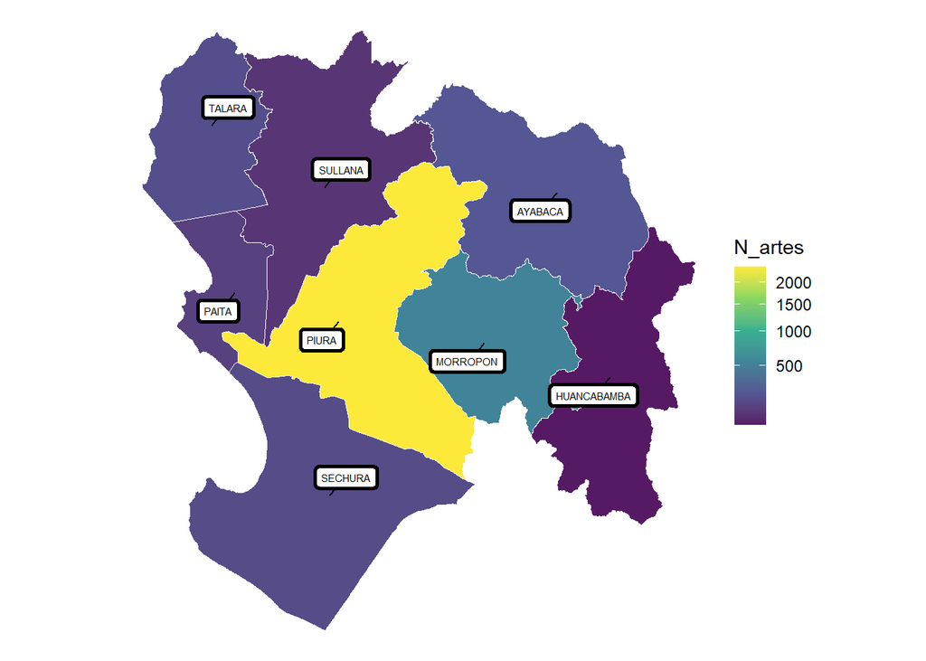

```r
grafico1 <- ggplot(data = datos %>%
                  filter(NOMBDEP=="PIURA")) +
  geom_sf(aes(fill = N_artes), show.legend = T, colour = "white")+
  geom_label_repel(aes(label = NOMBPROV,
                       geometry = geometry),
                   size = 2,
                   stat = "sf_coordinates",
                   min.segment.length = 0,
                   label.size = 1,
                   max.overlaps = Inf) +
  scale_fill_viridis_c(trans = "sqrt" ,  alpha = 0.9)+
  theme_void()

grafico1
```

### **Mapa distrital**

Observamos las categorias de la llave de distrito

```r
head(unique(df$DISTRITO))
```

```
## [1] "Catacaos"   "Piura"      "La Arena"   "Sullana"    "Cura Mori"
## [6] "Chulucanas"
```

```r
head(unique(m_distritos$NOMBDIST))
```

```
## [1] "CODO DEL POZUZO"        "TOURNAVISTA"            "ALEXANDER VON HUMBOLDT"
## [4] "IRAZOLA"                "NESHUYA"                "PADRE ABAD"
```

Escribimos en mayusculas df$DISTRITO para luego unir

```r
df$DISTRITO <- toupper(df$DISTRITO)
head(unique(df$DISTRITO))
```

```
## [1] "CATACAOS"   "PIURA"      "LA ARENA"   "SULLANA"    "CURA MORI"
## [6] "CHULUCANAS"
```

Unimos los datos por distrito y filtramos la data a los datos departamento Piura

```r
datos_dist <- m_distritos %>%
  left_join(df %>% count(DISTRITO, name = "N_artes"),
            by =c("NOMBDIST"= "DISTRITO")) %>%
  mutate(N_artes = as.numeric(N_artes)) %>%
  filter(NOMBDEP=="PIURA")
```

Visualizamos mapa por distrito

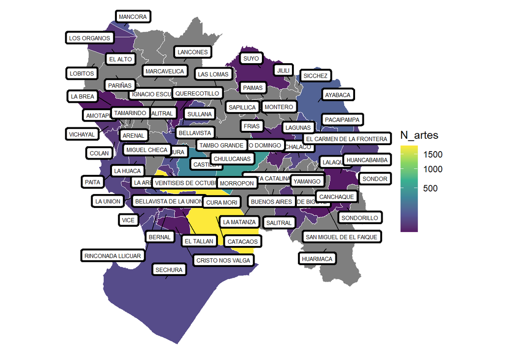

```r
grafico2 <- ggplot(data = datos_dist)  +
  geom_sf(aes(fill = N_artes), show.legend = T, colour = "white")+
  geom_label_repel(aes(label = NOMBDIST,
                       geometry = geometry),
                   size = 2,
                   stat = "sf_coordinates",
                   min.segment.length = 0,
                   label.size = 1,
                   max.overlaps = Inf) +
  scale_fill_viridis_c(trans = "sqrt" ,  alpha = 0.9)+
  theme_void()

grafico2
```